# Transaction Data - Part 2: RFM Analysis & Customer Segmentation

RFM Analysis is a practical method for segmenting and targeting customers for specific marketing activities more relevant to their purchasing behavior. RFM stands for Recency, Frequency and Monetary Value. This notebook will apply KMeans and Percentile based segmentation to the online retail dataset discussed in Part 1 of this series.

## Mount drive and import libraries and data

```python
# mount drive
from google.colab import drive
drive.mount('/content/drive')
```

```python
# import libraries
import pandas as pd
import matplotlib.pyplot as plt
plt.style.use('fivethirtyeight')
import seaborn as sns
import numpy as np
import datetime as dt
from sklearn.cluster import KMeans
```

```python
# import data
sales = pd.read_csv("./drive/My Drive/Data/EDA/sales.csv")
```

# Inspect

```python
sales.head(3)
```

|  | Unnamed: 0 | InvoiceNo | StockCode | Description | Quantity | InvoiceDate | UnitPrice | CustomerID | Country | Revenue |
| --- | --- | --- | --- | --- | --- | --- | --- | --- | --- | --- |
| 0 | 0 | 489434 | 85048 | 15CM CHRISTMAS GLASS BALL 20 LIGHTS | 12 | 2009-12-01 07:45:00 | 6.95 | 13085.0 | United Kingdom | 83.4 |
| 1 | 1 | 489434 | 79323P | PINK CHERRY LIGHTS | 12 | 2009-12-01 07:45:00 | 6.75 | 13085.0 | United Kingdom | 81.0 |
| 2 | 2 | 489434 | 79323W | WHITE CHERRY LIGHTS | 12 | 2009-12-01 07:45:00 | 6.75 | 13085.0 | United Kingdom | 81.0 |

```python
sales.info()
```

```
<class 'pandas.core.frame.DataFrame'>
RangeIndex: 1003653 entries, 0 to 1003652
Data columns (total 10 columns):
 #   Column       Non-Null Count    Dtype
---  ------       --------------    -----
 0   Unnamed: 0   1003653 non-null  int64
 1   InvoiceNo    1003653 non-null  int64
 2   StockCode    1003653 non-null  object
 3   Description  1003653 non-null  object
 4   Quantity     1003653 non-null  int64
 5   InvoiceDate  1003653 non-null  object
 6   UnitPrice    1003653 non-null  float64
 7   CustomerID   776840 non-null   float64
 8   Country      1003653 non-null  object
 9   Revenue      1003653 non-null  float64
dtypes: float64(3), int64(3), object(4)
memory usage: 76.6+ MB
```

```python
# convert invoice date to datetime object
sales['InvoiceDate'] = pd.to_datetime(sales['InvoiceDate'])

# drop unnecessary column
sales = sales.drop(columns=['Unnamed: 0'])

# drop rows where CustomerID is NA
sales = sales.dropna(subset=['CustomerID'])
```

```python
print('Start : ',sales['InvoiceDate'].min())
print('End : ',sales['InvoiceDate'].max())
```

```
Start :  2009-12-01 07:45:00
End :  2011-12-09 12:50:00
```

```python
# filter sales data for y/e 2011-12-09
sales11 = sales[sales.InvoiceDate > '2010-12-09 12:50:00']
```

```python
print('Start : ',sales11['InvoiceDate'].min())
print('End : ',sales11['InvoiceDate'].max())
print('Period : ',sales11['InvoiceDate'].max() - sales11['InvoiceDate'].min())
```

```
Start :  2010-12-09 12:59:00
End :  2011-12-09 12:50:00
Period :  364 days 23:51:00
```

## RFM

- Recency - days since last purchase ('today' minus date of last invoice)
- Frequency - number of orders over period (this could be number of unique invoices or orders, we shall use orders)
- Monetary value - total value of purchases over period

```python
# set 'today' as 1 day following the date of the latest transaction
today = sales11.InvoiceDate.max() + dt.timedelta(days=1)

# groupby customer id and calculate R, F, M. Note if unique invoices use 'nunique'
rfm = sales11.groupby('CustomerID').agg({'InvoiceDate': lambda x: (today - x.max()).days,
                                       'InvoiceNo': 'count',
                                       'Revenue': 'sum'})
rfm.columns = ['R', 'F', 'M']
```

```python
def rfmhist(df, bins):
  fig, axs = plt.subplots(1, 3, tight_layout=True, figsize=(15,4))
  for key, value in {'R':0, 'F':1, 'M':2}.items():
    axs[value].hist(df[key], bins=bins)
    axs[value].set_title(key)
```

```python
def rfmbox(df, cluster, outliars):
  fig, axs = plt.subplots(1, 3, tight_layout=True, figsize=(15,4))
  sns.boxplot(ax=axs[0], data=df, x=cluster, y='R', showfliers=outliars)
  sns.boxplot(ax=axs[1], data=df, x=cluster, y='F', showfliers=outliars)
  sns.boxplot(ax=axs[2], data=df, x=cluster, y='M', showfliers=outliars)
```

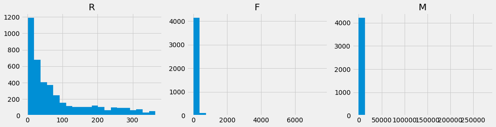

```python
rfmhist(rfm, 20)
```

```python
rfm.describe()
```

|  | R | F | M |
| --- | --- | --- | --- |
| count | 4266.000000 | 4266.000000 | 4266.000000 |
| mean | 88.275199 | 88.676746 | 1981.351153 |
| std | 94.580291 | 220.976837 | 8722.729193 |
| min | 1.000000 | 1.000000 | 3.750000 |
| 25% | 18.000000 | 17.000000 | 301.765000 |
| 50% | 50.000000 | 40.000000 | 656.655000 |
| 75% | 134.000000 | 96.750000 | 1613.905000 |
| max | 365.000000 | 7528.000000 | 279138.020000 |

```python
print(((rfm.F == 1).mean()*100).round(), '% of customers made 1 order over period')
```

```
2.0 % of customers made 1 order over period
```

Commentary:

- The "average customer" has spent c. £2000 over past year, spread over 89 orders with the last one occuring 88 days ago
- Considerible variance and skew across all variables

## Segmentation

Once the RFM values for each customer have been calculated, there are several different approaches to segment these customers into groups.

1. User-defined based on business requirements
2. Percentiles
3. Clustering algorithms

Each have their own advantages, limitations and use-cases.

Clustering algorithms such as K-Means can be a good place to start as they can find groups which have not been explicitly labeled in the data. This can either confirm assumptions about what types of groups exist or identify unknown groups. The added benefit of K-Means is that it is relatively simple to implement, scale and adapt to new examples.